# Introduction to Neural Networks: Bank Churn prediction

## Problem Statement

### Context

Businesses like banks which provide service have to worry about problem of 'Customer Churn' i.e. customers leaving and joining another service provider. It is important to understand which aspects of the service influence a customer's decision in this regard. Management can concentrate efforts on improvement of service, keeping in mind these priorities.

### Objective

You as a Data scientist with the bank need to build a neural network based classifier that can determine whether a customer will leave the bank or not in the next 6 months.

### Data Dictionary:

- CustomerId: Unique ID which is assigned to each customer
- Surname: Last name of the customer
- CreditScore: It defines the credit history of the customer.
- Geography: A customer’s location
- Gender: It defines the Gender of the customer
- Age: Age of the customer
- Tenure: Number of years for which the customer has been with the bank
- NumOfProducts: refers to the number of products that a customer has purchased through the bank.
- Balance: Account balance
- HasCrCard: It is a categorical variable which decides whether the customer has credit card or not.
- EstimatedSalary: Estimated salary
- isActiveMember: Is is a categorical variable which decides whether the customer is active member of the bank or not ( Active member in the sense, using bank products regularly, making transactions etc )
- Exited : whether or not the customer left the bank within six month. It can take two values ** 0=No ( Customer did not leave the bank ) ** 1=Yes ( Customer left the bank )

## Importing necessary libraries

```python
!pip install scikeras
```

```python
# Libraries to help with reading and manipulating data
import pandas as pd
import numpy as np
# Library to split data
from sklearn.model_selection import train_test_split
# Library to encode the variables
from sklearn import preprocessing
# To plot confusion matrix
from sklearn.metrics import confusion_matrix
# libaries to help with data visualization
import matplotlib.pyplot as plt
import seaborn as sns
# library to import to standardize the data
from sklearn.preprocessing import StandardScaler
#To import different metrics
from sklearn import metrics
from tensorflow.keras import backend
# Library to avoid the warnings
import warnings
warnings.filterwarnings("ignore")
# importing different functions to build models
from tensorflow.keras.models import Sequential
from tensorflow.keras.layers import Dense, Dropout
from scikeras.wrappers import KerasClassifier
import tensorflow as tf
# importing GridSearch CV
from sklearn.model_selection import GridSearchCV
# importing roc_curve to plot
from sklearn.metrics import roc_curve
from matplotlib import pyplot
# importing SMOTE
from imblearn.over_sampling import SMOTE
# importing metrics
from sklearn import metrics
import random
#Importing classback API
from keras import callbacks
```

## Loading the dataset

```python
Data = pd.read_csv('/content/Churn.csv')
```

```python
#Check Num Rows and columns in data
num_rows, num_columns = Data.shape
print(f"The number of rows is: {num_rows}")
print(f"The number of columns is: {num_columns}")
```

```
The number of rows is: 10000
The number of columns is: 14
```

## Data Overview

```python
# View first 5 rows of data
Data.head()
```

|  | RowNumber | CustomerId | Surname | CreditScore | Geography | Gender | Age | Tenure | Balance | NumOfProducts | HasCrCard | IsActiveMember | EstimatedSalary | Exited |
| --- | --- | --- | --- | --- | --- | --- | --- | --- | --- | --- | --- | --- | --- | --- |
| 0 | 1 | 15634602 | Hargrave | 619 | France | Female | 42 | 2 | 0.00 | 1 | 1 | 1 | 101348.88 | 1 |
| 1 | 2 | 15647311 | Hill | 608 | Spain | Female | 41 | 1 | 83807.86 | 1 | 0 | 1 | 112542.58 | 0 |
| 2 | 3 | 15619304 | Onio | 502 | France | Female | 42 | 8 | 159660.80 | 3 | 1 | 0 | 113931.57 | 1 |
| 3 | 4 | 15701354 | Boni | 699 | France | Female | 39 | 1 | 0.00 | 2 | 0 | 0 | 93826.63 | 0 |
| 4 | 5 | 15737888 | Mitchell | 850 | Spain | Female | 43 | 2 | 125510.82 | 1 | 1 | 1 | 79084.10 | 0 |

- RowNumber prob not important
- CustomerID prob not important
- First 5 all female

```python
# View last 5 rows of Data
Data.tail()
```

|  | RowNumber | CustomerId | Surname | CreditScore | Geography | Gender | Age | Tenure | Balance | NumOfProducts | HasCrCard | IsActiveMember | EstimatedSalary | Exited |
| --- | --- | --- | --- | --- | --- | --- | --- | --- | --- | --- | --- | --- | --- | --- |
| 9995 | 9996 | 15606229 | Obijiaku | 771 | France | Male | 39 | 5 | 0.00 | 2 | 1 | 0 | 96270.64 | 0 |
| 9996 | 9997 | 15569892 | Johnstone | 516 | France | Male | 35 | 10 | 57369.61 | 1 | 1 | 1 | 101699.77 | 0 |
| 9997 | 9998 | 15584532 | Liu | 709 | France | Female | 36 | 7 | 0.00 | 1 | 0 | 1 | 42085.58 | 1 |
| 9998 | 9999 | 15682355 | Sabbatini | 772 | Germany | Male | 42 | 3 | 75075.31 | 2 | 1 | 0 | 92888.52 | 1 |
| 9999 | 10000 | 15628319 | Walker | 792 | France | Female | 28 | 4 | 130142.79 | 1 | 1 | 0 | 38190.78 | 0 |

- 2 in last 5 rows with 0 balance
- 3/5 male
- 4/5 in France

```python
# Check Data Types
Data.info()
```

```
<class 'pandas.core.frame.DataFrame'>
RangeIndex: 10000 entries, 0 to 9999
Data columns (total 14 columns):
 #   Column           Non-Null Count  Dtype
---  ------           --------------  -----
 0   RowNumber        10000 non-null  int64
 1   CustomerId       10000 non-null  int64
 2   Surname          10000 non-null  object
 3   CreditScore      10000 non-null  int64
 4   Geography        10000 non-null  object
 5   Gender           10000 non-null  object
 6   Age              10000 non-null  int64
 7   Tenure           10000 non-null  int64
 8   Balance          10000 non-null  float64
 9   NumOfProducts    10000 non-null  int64
 10  HasCrCard        10000 non-null  int64
 11  IsActiveMember   10000 non-null  int64
 12  EstimatedSalary  10000 non-null  float64
 13  Exited           10000 non-null  int64
dtypes: float64(2), int64(9), object(3)
memory usage: 1.1+ MB
```

```python
# Get Statistical summary
Data.describe()
```

|  | RowNumber | CustomerId | CreditScore | Age | Tenure | Balance | NumOfProducts | HasCrCard | IsActiveMember | EstimatedSalary | Exited |
| --- | --- | --- | --- | --- | --- | --- | --- | --- | --- | --- | --- |
| count | 10000.00000 | 1.000000e+04 | 10000.000000 | 10000.000000 | 10000.000000 | 10000.000000 | 10000.000000 | 10000.00000 | 10000.000000 | 10000.000000 | 10000.000000 |
| mean | 5000.50000 | 1.569094e+07 | 650.528800 | 38.921800 | 5.012800 | 76485.889288 | 1.530200 | 0.70550 | 0.515100 | 100090.239881 | 0.203700 |
| std | 2886.89568 | 7.193619e+04 | 96.653299 | 10.487806 | 2.892174 | 62397.405202 | 0.581654 | 0.45584 | 0.499797 | 57510.492818 | 0.402769 |
| min | 1.00000 | 1.556570e+07 | 350.000000 | 18.000000 | 0.000000 | 0.000000 | 1.000000 | 0.00000 | 0.000000 | 11.580000 | 0.000000 |
| 25% | 2500.75000 | 1.562853e+07 | 584.000000 | 32.000000 | 3.000000 | 0.000000 | 1.000000 | 0.00000 | 0.000000 | 51002.110000 | 0.000000 |
| 50% | 5000.50000 | 1.569074e+07 | 652.000000 | 37.000000 | 5.000000 | 97198.540000 | 1.000000 | 1.00000 | 1.000000 | 100193.915000 | 0.000000 |
| 75% | 7500.25000 | 1.575323e+07 | 718.000000 | 44.000000 | 7.000000 | 127644.240000 | 2.000000 | 1.00000 | 1.000000 | 149388.247500 | 0.000000 |
| max | 10000.00000 | 1.581569e+07 | 850.000000 | 92.000000 | 10.000000 | 250898.090000 | 4.000000 | 1.00000 | 1.000000 | 199992.480000 | 1.000000 |

- Mean credit score around 650
- Mean exited around .20
- Mean number of products around 1.5

```python
#Unique values in each column
Data.nunique()
```

```
RowNumber          10000
CustomerId         10000
Surname             2932
CreditScore          460
Geography              3
Gender                 2
Age                   70
Tenure                11
Balance             6382
NumOfProducts          4
HasCrCard              2
IsActiveMember         2
EstimatedSalary     9999
Exited                 2
dtype: int64
```

- 10,000 unique customer ids
- 2,932 unique Surnames
- 9999 unique Estimated Salaries

```python
# Drop columns that are unique for all users
Data = Data.drop(['RowNumber', 'CustomerId', 'Surname'], axis=1)
```

```python
Data.duplicated().sum()
```

```
0
```

- No duplicated values

# Ensure no missing values

```python
# Ensure no missing values in data
# Check for missing values in each column
missing_values = Data.isnull().sum()

# Display columns with missing values (if any)
columns_with_missing_values = missing_values[missing_values > 0]

if columns_with_missing_values.empty:
    print("Hooray! There are no missing values in the data! 🌟")
else:
    print("Columns with missing values:")
    print(columns_with_missing_values)
```

```
Hooray! There are no missing values in the data! 🌟
```

## Exploratory Data Analysis

- EDA is an important part of any project involving data.
- It is important to investigate and understand the data better before building a model with it.
- A few questions have been mentioned below which will help you approach the analysis in the right manner and generate insights from the data.
- A thorough analysis of the data, in addition to the questions mentioned below, should be done.

**Questions**:

1. What is the distribution of the credit score of customers? Are there any noticeable patterns or outliers in the distribution?
2. How many active members are there with the bank?
3. How are the different customer attributes correlated to each other?
4. Who is churning more when compared to males and females?
5. Customers from which geographical part are churning more?
1. What is the distribution of the credit score of customers? Are there any noticeable patterns or outliers in the distribution?

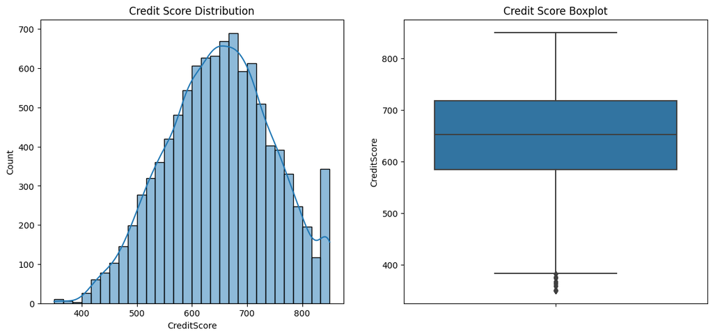

```python
# Set up the matplotlib figure
plt.figure(figsize=(14, 6))

# 1st subplot for the histogram
plt.subplot(1, 2, 1)
sns.histplot(Data['CreditScore'], bins=30, kde=True)
plt.title('Credit Score Distribution')

# 2nd subplot for the boxplot
plt.subplot(1, 2, 2)
sns.boxplot(y=Data['CreditScore'])
plt.title('Credit Score Boxplot')

# Show the plots
plt.show()
```

- The histogram shows that credit scores are somewhat normally distributed with a peak around the 650-700 range, indicating that most customers have a credit score within this range.
- The box plot indicates there are some potential outliers on the lower end of the distribution, as shown by the points below the bottom whisker.
- These outliers might represent customers with particularly low credit scores, which could be of interest when analyzing credit risk or the potential for churn.

```python
# Calculate the IQR for CreditScore
Q1 = Data['CreditScore'].quantile(0.25)
Q3 = Data['CreditScore'].quantile(0.75)
IQR = Q3 - Q1

# Determine the outliers
outliers = Data[(Data['CreditScore'] < (Q1 - 1.5 * IQR)) | (Data['CreditScore'] > (Q3 + 1.5 * IQR))]

# Number of outliers
outlier_count = outliers['CreditScore'].count()

# Display the IQR and the number of outliers
IQR, outlier_count, outliers['CreditScore'].describe()
```

```
(134.0,
 15,
 count     15.000000
 mean     361.333333
 std       11.362009
 min      350.000000
 25%      350.000000
 50%      359.000000
 75%      370.000000
 max      382.000000
 Name: CreditScore, dtype: float64)
```

- The interquartile range (IQR) for the credit scores is 134.
- Based on the IQR, there are 15 credit scores that are considered outliers, all of which are on the lower end of the spectrum.
- These outliers have credit scores ranging from 350 to 382, which are significantly lower than the typical range of credit scores in the dataset.
- Such low credit scores might indicate customers who are potentially at higher risk for credit default or other financial issues, and this could be a factor in customer churn or other business considerations.
2. How many active members are there with the bank?

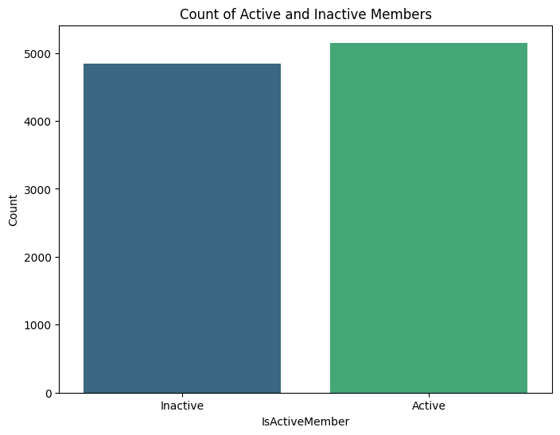

```
1    5151
0    4849
Name: IsActiveMember, dtype: int64
```

```python
# Count the number of active and inactive members
active_inactive_counts = Data['IsActiveMember'].value_counts()

# Plotting the counts
plt.figure(figsize=(8, 6))
sns.barplot(x=active_inactive_counts.index, y=active_inactive_counts.values, palette='viridis')
plt.title('Count of Active and Inactive Members')
plt.xlabel('IsActiveMember')
plt.ylabel('Count')
plt.xticks([0, 1], ['Inactive', 'Active'])  # Rename the x-ticks for clarity

# Display the plot
plt.show()

# Show the actual counts
active_inactive_counts
```

- There are 5,151 active members (represented by 1).
- There are 4,849 inactive members (represented by 0).
3. How are the different customer attributes correlated to each other?

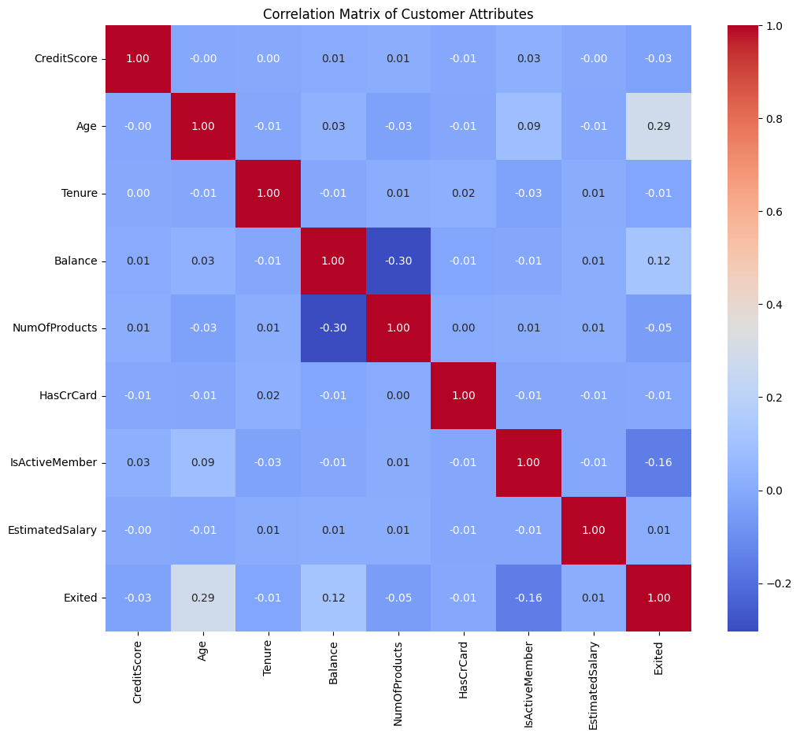

```python
# Calculate the correlation matrix
correlation_matrix = Data.corr()

# Plotting the heatmap
plt.figure(figsize=(12, 10))
sns.heatmap(correlation_matrix, annot=True, fmt=".2f", cmap='coolwarm')
plt.title('Correlation Matrix of Customer Attributes')
plt.show()
```

- Age & Exited have a positive correlation of 0.29
- NumofProduct & Balance has a negative correlation of -0.30
- IsActiveMember & Exited has a negative correlation of -0.16
4. Who is churning more when compared to males and females?

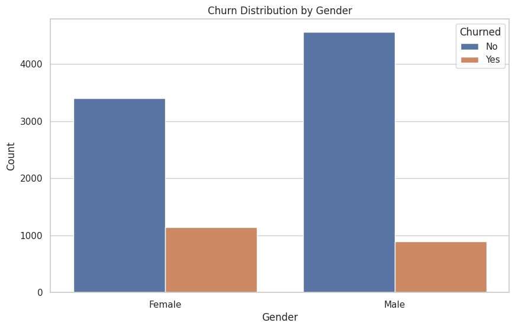

```python
# Setting the aesthetic style of the plots
sns.set(style="whitegrid")

# Creating a countplot to show the distribution of churn across genders
plt.figure(figsize=(10, 6))
sns.countplot(x='Gender', hue='Exited', data=Data)

# Adding titles and labels
plt.title('Churn Distribution by Gender')
plt.xlabel('Gender')
plt.ylabel('Count')
plt.legend(title='Churned', labels=['No', 'Yes'])

plt.show()
```

- Females more likely to churn than males
- Female churn over 1000
- Male churn under 1000
5. Customers from which geographical part are churning more?

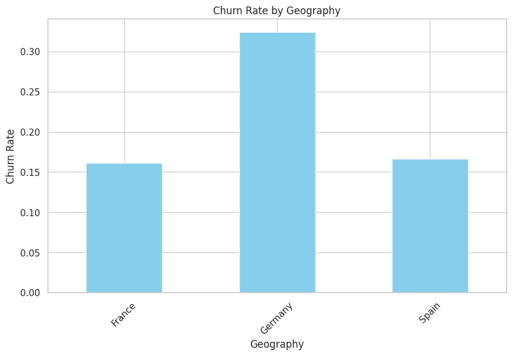

```
Geography
France     0.161548
Germany    0.324432
Spain      0.166734
Name: Exited, dtype: float64
```

```python
# To find out which geographical region has the highest churn rate, we'll group the data by 'Geography'
# and calculate the churn rate for each region

geo_churn_rates = Data.groupby('Geography')['Exited'].mean()

# Plotting the churn rate by Geography
plt.figure(figsize=(10, 6))
geo_churn_rates.plot(kind='bar', color='skyblue')

# Adding titles and labels
plt.title('Churn Rate by Geography')
plt.xlabel('Geography')
plt.ylabel('Churn Rate')
plt.xticks(rotation=45)

plt.show()

geo_churn_rates
```

- Germany highest churn rate
- France and Spain have significantly lower churn rates
- France at around 16.15% and Spain at approximately 16.67%.

## Univariate Analysis

```python
# function to plot a boxplot and a histogram along the same scale.


def histogram_boxplot(data, feature, figsize=(12, 7), kde=False, bins=None):
    """
    Boxplot and histogram combined

    data: dataframe
    feature: dataframe column
    figsize: size of figure (default (12,7))
    kde: whether to show the density curve (default False)
    bins: number of bins for histogram (default None)
    """
    f2, (ax_box2, ax_hist2) = plt.subplots(
        nrows=2,  # Number of rows of the subplot grid= 2
        sharex=True,  # x-axis will be shared among all subplots
        gridspec_kw={"height_ratios": (0.25, 0.75)},
        figsize=figsize,
    )  # creating the 2 subplots
    sns.boxplot(
        data=data, x=feature, ax=ax_box2, showmeans=True, color="violet"
    )  # boxplot will be created and a star will indicate the mean value of the column
    sns.histplot(
        data=data, x=feature, kde=kde, ax=ax_hist2, bins=bins, palette="winter"
    ) if bins else sns.histplot(
        data=data, x=feature, kde=kde, ax=ax_hist2
    )  # For histogram
    ax_hist2.axvline(
        data[feature].mean(), color="green", linestyle="--"
    )  # Add mean to the histogram
    ax_hist2.axvline(
        data[feature].median(), color="black", linestyle="-"
    )  # Add median to the histogram
```

```python
# function to create labeled barplots


def labeled_barplot(data, feature, perc=False, n=None):
    """
    Barplot with percentage at the top

    data: dataframe
    feature: dataframe column
    perc: whether to display percentages instead of count (default is False)
    n: displays the top n category levels (default is None, i.e., display all levels)
    """

    total = len(data[feature])  # length of the column
    count = data[feature].nunique()
    if n is None:
        plt.figure(figsize=(count + 1, 5))
    else:
        plt.figure(figsize=(n + 1, 5))

    plt.xticks(rotation=90, fontsize=15)
    ax = sns.countplot(
        data=data,
        x=feature,
        palette="Paired",
        order=data[feature].value_counts().index[:n].sort_values(),
    )

    for p in ax.patches:
        if perc == True:
            label = "{:.1f}%".format(
                100 * p.get_height() / total
            )  # percentage of each class of the category
        else:
            label = p.get_height()  # count of each level of the category

        x = p.get_x() + p.get_width() / 2  # width of the plot
        y = p.get_height()  # height of the plot

        ax.annotate(
            label,
            (x, y),
            ha="center",
            va="center",
            size=12,
            xytext=(0, 5),
            textcoords="offset points",
        )  # annotate the percentage

    plt.show()  # show the plot
```

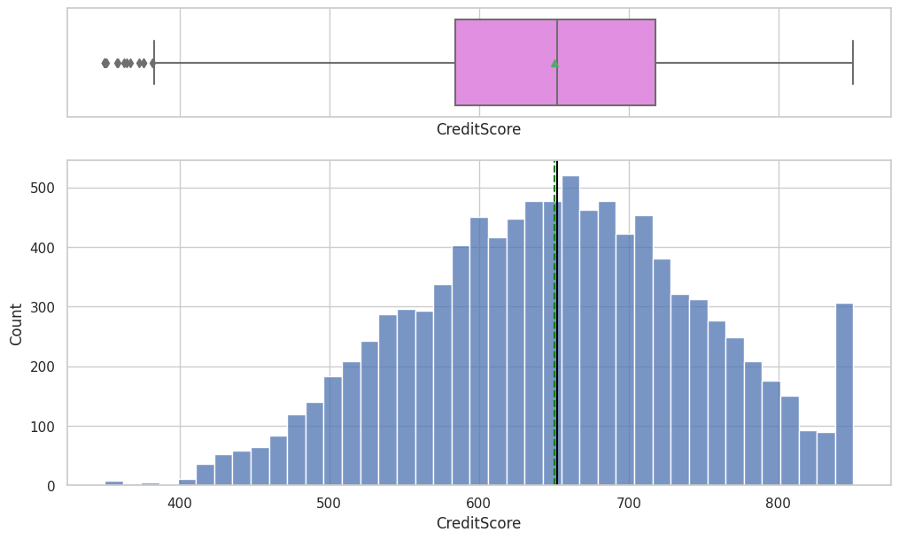

```python
#Observations on credit score
histogram_boxplot(Data,'CreditScore')
```

- Normal distribuiton
- No significant skew
- A few outliers seen in the boxplot

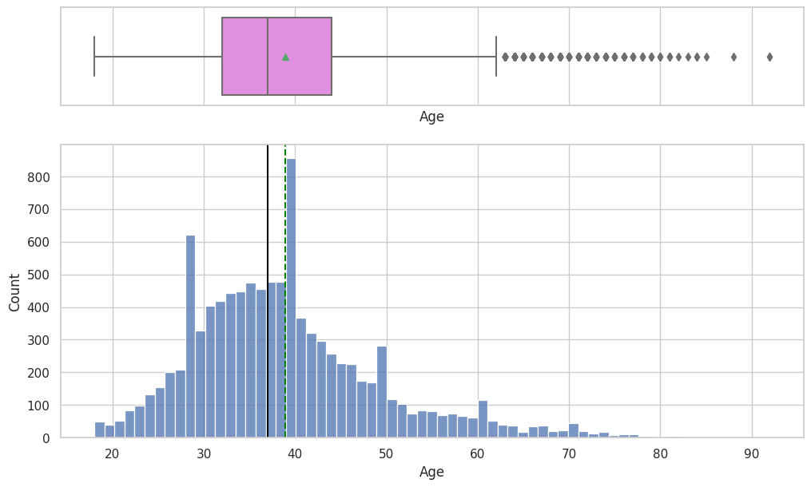

```python
# Observations on Age
histogram_boxplot(Data, 'Age')
```

1. Skewness: The distribution of age is right-skewed, indicating a larger number of younger customers in the dataset.
2. Central Tendency: The median age (indicated by the black line) is lower than the mean age (green line), which is typical for a right-skewed distribution.
3. Outliers: There are outliers on the higher age side, suggesting the presence of significantly older customers compared to the majority.

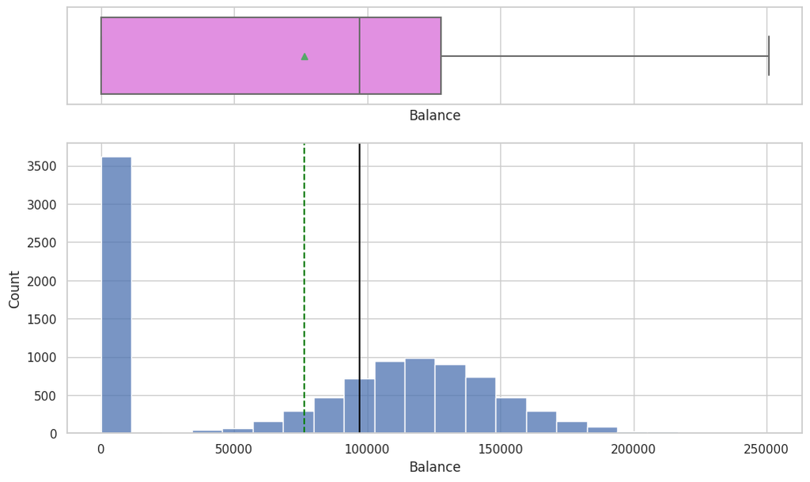

```python
# Observations on Balance
histogram_boxplot(Data, 'Balance')
```

- Bimodal Distribution: The histogram shows a bimodal distribution with one peak near zero and another around the 100,000 to 150,000 range.
- Zero Balance: A substantial proportion of customers have zero or very low balance, as indicated by the first peak.
- Outliers: The boxplot does not indicate significant outliers, suggesting that most customers' balances are within a reasonable range.

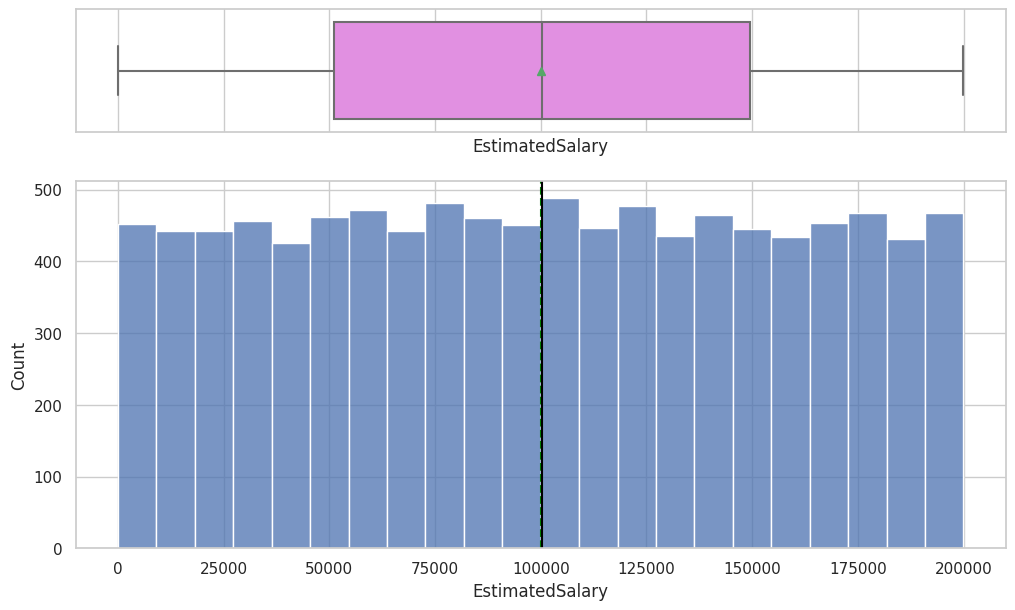

```python
# Observations on Estimated Salary
histogram_boxplot(Data, 'EstimatedSalary')
```

- Uniform Distribution: The distribution of estimated salaries appears quite uniform, indicating that customers' salaries are evenly spread across the range.
- Central Tendency: The mean and median are almost aligned, which is expected in a uniform distribution.
- No Significant Outliers: The boxplot shows a lack of significant outliers, suggesting that extreme salaries are not common in this dataset.

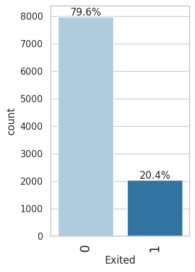

```python
#Observations on Exited
labeled_barplot(Data, "Exited", perc=True)
```

- Churn Rate: A significant minority of customers have churned (Exited). The percentage labeling on the bar graph shows a clear visual representation of the churn rate.
- Retention: The majority of customers are retained, as indicated by the larger bar for '0' (did not exit).
- Churn Visualization: The visual representation makes it easy to compare the scale of churn versus retention, highlighting the proportion of customers that the bank is losing.

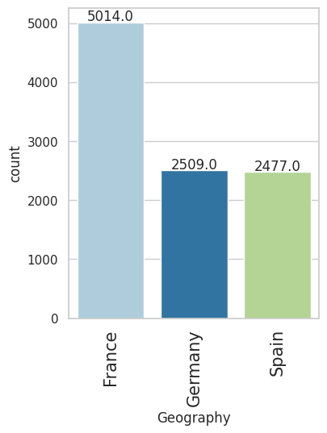

```python
#Observations on Geography
labeled_barplot(Data, "Geography")
```

- Distribution by Region: The bank's customers are not evenly distributed across regions. France has the highest number of customers, followed by Germany and Spain.
- Market Penetration: The bar heights suggest that the bank has a stronger presence or market penetration in France compared to Germany and Spain.
- Potential Market Analysis: This visualization can help in analyzing market-specific strategies or products, considering the varying customer base in different regions.

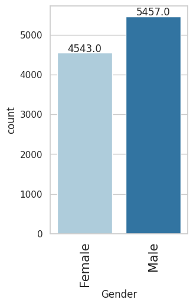

```python
#Observations on Gender
labeled_barplot(Data, "Gender")
```

- Gender Distribution: The number of male customers is slightly higher than female customers.
- Visual Representation of Gender Balance: The graph provides a straightforward visual representation of the gender distribution among the customers, which is relatively balanced.
- Targeted Services: Understanding the gender distribution can aid in developing targeted services or marketing strategies for different customer segments

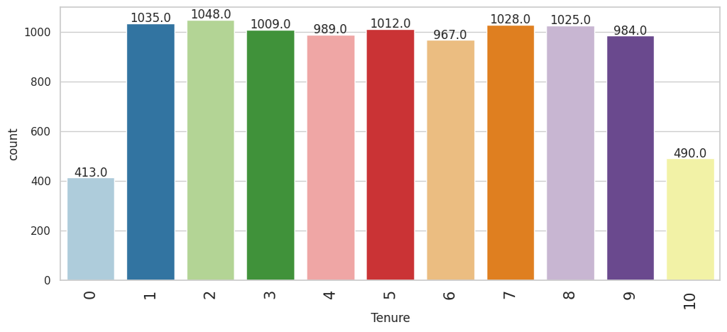

```python
#Observations on Tenure
labeled_barplot(Data, "Tenure")
```

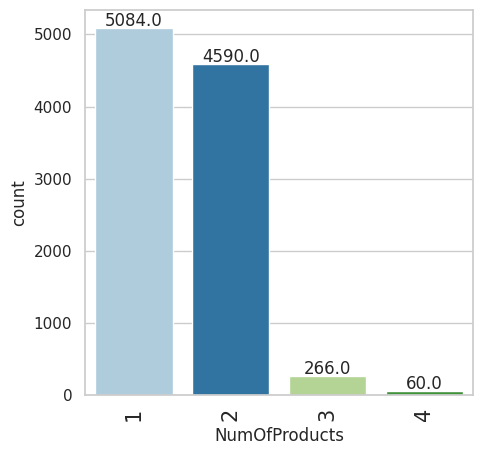

```python
#Observations on Number of Products
labeled_barplot(Data, "NumOfProducts")
```

- Preference for Fewer Products: A large majority of customers have 1 or 2 banking products, with very few opting for 3 or 4 products.
- Limited Uptake of Multiple Products: The low numbers for 3 and 4 products indicate limited success in cross-selling or up-selling more complex banking products.
- Product Strategy: These insights can guide product strategy, focusing on the most popular products and understanding the barriers to adopting more products.

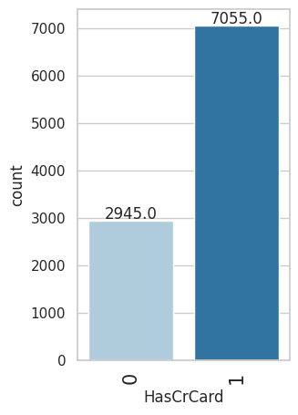

```python
#Observations on Has Credit Card
labeled_barplot(Data, "HasCrCard")
```

- High Credit Card Ownership: A significant majority of customers possess a credit card.
- Banking Services Penetration: The high credit card ownership reflects the bank's penetration in terms of basic banking services.
- Credit Card as a Popular Product: This suggests that credit card services are popular and widely accepted among the bank's customers, possibly indicating a key area for continued focus or promotional efforts.

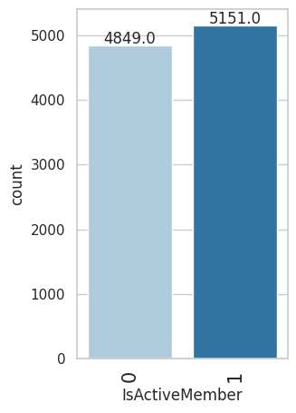

```python
#Observations on Is Active Member
labeled_barplot(Data, "IsActiveMember")
```

- Balanced Membership Activity: There's a nearly even split between active and inactive members, indicating a balanced customer base in terms of engagement.
- Engagement Strategies: This highlights the potential for strategies aimed at increasing engagement among inactive members.
- Importance of Active Membership: Understanding what drives active membership can help tailor services and communications to boost customer engagement and satisfaction.

## Bivariate Analysis

```python
# function to plot stacked bar chart


def stacked_barplot(data, predictor, target):
    """
    Print the category counts and plot a stacked bar chart

    data: dataframe
    predictor: independent variable
    target: target variable
    """
    count = data[predictor].nunique()
    sorter = data[target].value_counts().index[-1]
    tab1 = pd.crosstab(data[predictor], data[target], margins=True).sort_values(
        by=sorter, ascending=False
    )
    print(tab1)
    print("-" * 120)
    tab = pd.crosstab(data[predictor], data[target], normalize="index").sort_values(
        by=sorter, ascending=False
    )
    tab.plot(kind="bar", stacked=True, figsize=(count + 1, 5))
    plt.legend(
        loc="lower left",
        frameon=False,
    )
    plt.legend(loc="upper left", bbox_to_anchor=(1, 1))
    plt.show()
```

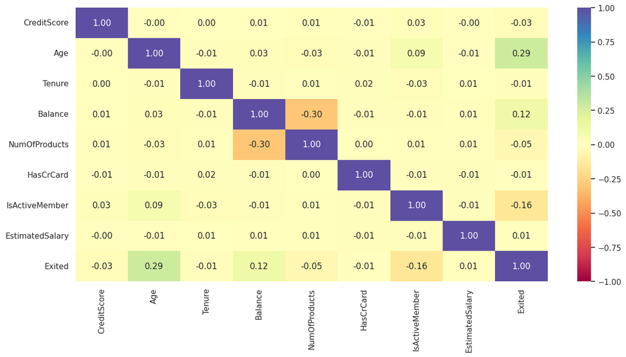

```python
# Correlation plot
plt.figure(figsize=(15, 7))
sns.heatmap(Data.corr(), annot=True, vmin=-1, vmax=1, fmt=".2f", cmap="Spectral")
plt.show()
```

- Variable Relationships: The heatmap shows the correlation coefficients between pairs of variables, which can reveal relationships and trends.
- Strong and Weak Correlations: Positive numbers indicate a positive correlation, while negative numbers indicate a negative correlation. Closer the value is to 1 or -1, the stronger the correlation.
- Insightful for Feature Selection: This can be insightful for feature selection in predictive modeling, as highly correlated features can cause multicollinearity.

```
Exited        0     1    All
Geography
All        7963  2037  10000
Germany    1695   814   2509
France     4204   810   5014
Spain      2064   413   2477
------------------------------------------------------------------------------------------------------------------------
```

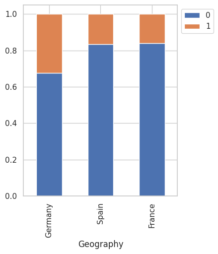

```python
# Exited Vs Geography
stacked_barplot(Data, "Geography", "Exited" )
```

- Churn by Region: The stacked bar chart shows the churn rate (Exited) across different geographic regions. Germany has a notably higher churn rate compared to France and Spain.
- Customer Retention: France and Spain have better customer retention as indicated by the larger proportion of '0' (did not exit) in their bars.
- Targeted Strategies: This insight could be crucial for developing region-specific customer retention strategies.

```
Gender     Female  Male    All
Geography
All          4543  5457  10000
France       2261  2753   5014
Germany      1193  1316   2509
Spain        1089  1388   2477
------------------------------------------------------------------------------------------------------------------------
```

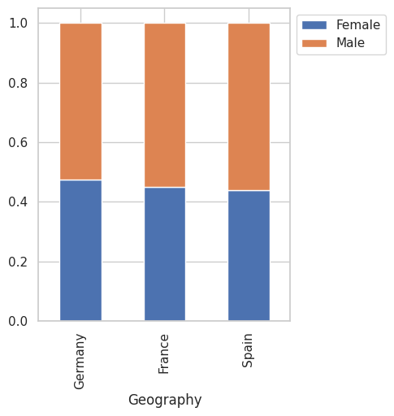

```python
# Exited Vs Gender
stacked_barplot(Data, "Geography", "Gender" )
```

- Gender Distribution by Region: This chart shows the gender distribution across different regions. It doesn't relate to the 'Exited' variable, which seems to be a mistake in the function call.
- Balanced Distribution: Gender distribution seems relatively balanced across regions, with a slightly higher proportion of males.
- Regional Marketing: This could be used to tailor marketing strategies according to the gender demographics in each region.

```
HasCrCard     0     1    All
Geography
All        2945  7055  10000
France     1471  3543   5014
Spain       756  1721   2477
Germany     718  1791   2509
------------------------------------------------------------------------------------------------------------------------
```

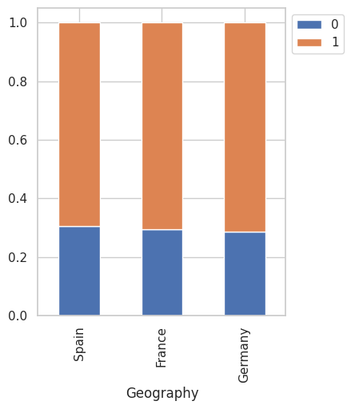

```python
# Exited Vs Has Credit Card
stacked_barplot(Data, "Geography", "HasCrCard" )
```

```
IsActiveMember     0     1    All
Exited
All             4849  5151  10000
0               3547  4416   7963
1               1302   735   2037
------------------------------------------------------------------------------------------------------------------------
```

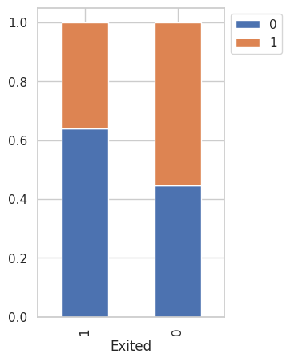

```python
# Exited Vs Is active member
stacked_barplot(Data, "Exited", "IsActiveMember" )
```

- Inactivity and Churn: A higher proportion of customers who exited were not active members, suggesting a strong relationship between inactivity and churn.
- Active Member Retention: Active members are more likely to be retained, as shown by the larger proportion of '1' (active) in the '0' (did not exit) bar.
- Engagement Strategies: This highlights the importance of engagement strategies in customer retention.

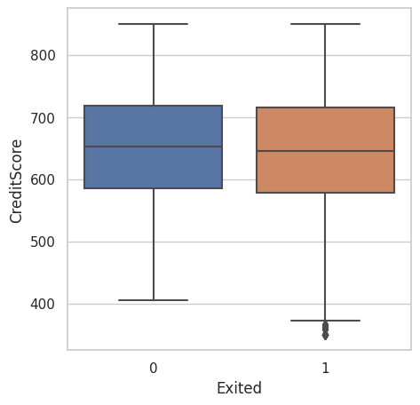

```python
# Exited Vs Credit Score
plt.figure(figsize=(5,5))
sns.boxplot(y='CreditScore',x='Exited',data=Data)
plt.show()
```

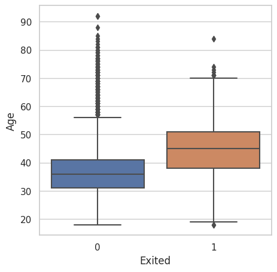

```python
# Exited Vs Age
plt.figure(figsize=(5,5))
sns.boxplot(y='Age',x='Exited',data=Data)
plt.show()
```

- Higher Age in Exited Customers: Customers who exited tend to be older, as indicated by the higher median age in the 'Exited = 1' category.
- Younger Customer Retention: Younger customers are more likely to be retained.
- Age as a Factor in Churn: Age seems to be a significant factor in churn, with older customers being more likely to leave.

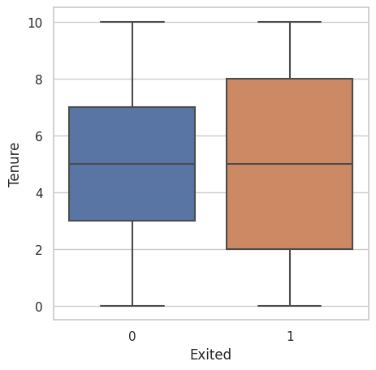

```python
# Exited Vs Tenure
plt.figure(figsize=(5,5))
sns.boxplot(y='Tenure',x='Exited',data=Data)
plt.show()
```

- Tenure Distribution: The distribution of tenure is similar for both churned and retained customers, indicating that tenure alone may not be a strong predictor of churn.
- No Clear Pattern: There's no clear pattern in tenure that distinguishes between those who exit and those who stay.
- Customer Loyalty: The lack of a distinct difference in tenure suggests that customer loyalty, as measured by tenure, might not be the only factor influencing the decision to exit

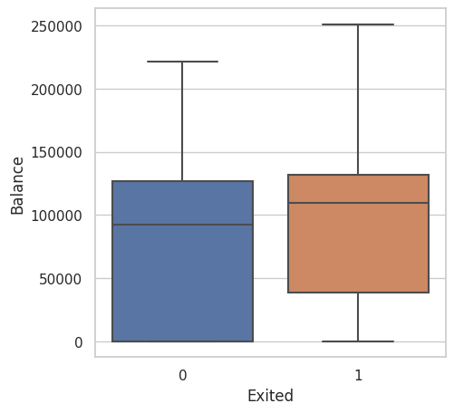

```python
# Exited Vs Balance
plt.figure(figsize=(5,5))
sns.boxplot(y='Balance',x='Exited',data=Data)
plt.show()
```

- Higher Balances in Exited Customers: Customers who exited tend to have higher balances, as indicated by the higher median balance in the 'Exited = 1' category.
- Balance as a Churn Factor: This suggests that customers with higher balances are more likely to churn.
- Retention of Lower Balance Customers: Customers with lower balances are more likely to be retained, possibly indicating satisfaction or lack of alternatives.

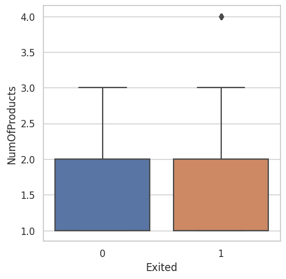

```python
# Exited Vs Number of Products
plt.figure(figsize=(5,5))
sns.boxplot(y='NumOfProducts',x='Exited',data=Data)
plt.show()
```

- Product Ownership and Churn: Customers with one product have a higher tendency to exit, while those with two products are more likely to stay.
- Fewer Products, Higher Churn: A significant number of customers who churn have only one product, indicating potential dissatisfaction or unmet needs.
- Risk with Multiple Products: Owning more than two products also increases the risk of churn, possibly due to complexity or service issues.

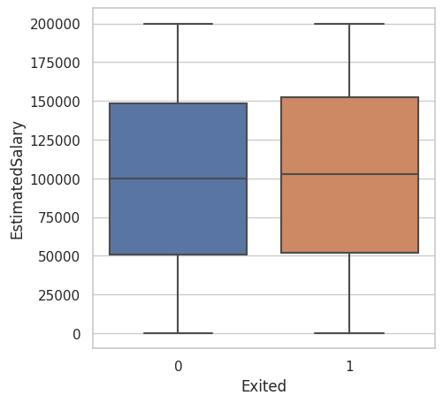

```python
# Exited Vs Estimated Salary
plt.figure(figsize=(5,5))
sns.boxplot(y='EstimatedSalary',x='Exited',data=Data)
plt.show()
```

- Salary Not a Strong Differentiator: The estimated salary distribution is similar for both exited and retained customers, suggesting that salary alone is not a major factor in churn.
- Wide Salary Range: Customers across a wide range of salaries both exit and stay, indicating that factors other than salary influence the decision.
- Uniformity Across Salaries: The similarity in interquartile ranges and medians across both categories suggests uniformity in salary distribution regardless of churn status

## Data Preprocessing

- Missing value treatment
- Feature engineering (if needed)
- Outlier detection and treatment (if needed)
- Preparing data for modeling
- Any other preprocessing steps (if needed)

```python
X = Data.drop(['Exited'], axis=1)
y = Data[['Exited']]
```

```python
# Splitting the dataset into the Training and Testing set.

X_large, X_test, y_large, y_test = train_test_split(X, y, test_size=0.2, random_state=42, stratify=y, shuffle=True)
```

```python
X_train, X_val, y_train, y_val = train_test_split(X_large, y_large, test_size=0.2, random_state=42, stratify=y_large, shuffle=True)
```

```python
X_train = pd.get_dummies(X_train, columns=["Geography", "Gender"], drop_first=True)
X_test = pd.get_dummies(X_test, columns=["Geography", "Gender"], drop_first=True)
X_val = pd.get_dummies(X_val, columns=["Geography", "Gender"], drop_first=True)
```

```python
sc = StandardScaler()
temp = sc.fit(X_train[["CreditScore", "Age", "Tenure", "Balance", "EstimatedSalary"]])
X_train[["CreditScore", "Age", "Tenure", "Balance", "EstimatedSalary"]] = temp.transform(X_train[["CreditScore", "Age", "Tenure", "Balance", "EstimatedSalary"]])
X_test[["CreditScore", "Age", "Tenure", "Balance", "EstimatedSalary"]] = temp.transform(X_test[["CreditScore", "Age", "Tenure", "Balance", "EstimatedSalary"]])
X_val[["CreditScore", "Age", "Tenure", "Balance", "EstimatedSalary"]] = temp.transform(X_val[["CreditScore", "Age", "Tenure", "Balance", "EstimatedSalary"]])
```

## Model Building

### Model Evaluation Criterion

**The Model can make false predications as predicting a customer is:**

**The more important case:**

- Predicting customer is not exiting but they are exiting. This could lead to a loss for the banks because of false ID the bank won't be able to take steps to make customer not churn.

**How to reduce loss (Reduce False Negative)**

- The bank wants to maximize recall. The higher the recall the lower the chance of a false Negative. So the focus should be increasing recall which shrinks false Negative. Another way to view this is as identifying True Positive. The ultimate goal is for the bank to retain customers.

```python
# Confusion Matrix

def make_confusion_matrix(cf,
                          group_names=None,
                          categories='auto',
                          count=True,
                          percent=True,
                          cbar=True,
                          xyticks=True,
                          xyplotlabels=True,
                          sum_stats=True,
                          figsize=None,
                          cmap='Blues',
                          title=None):
    '''
    This function will make a pretty plot of an sklearn Confusion Matrix cm using a Seaborn heatmap visualization.
    Arguments
    '''


    # CODE TO GENERATE TEXT INSIDE EACH SQUARE
    blanks = ['' for i in range(cf.size)]

    if group_names and len(group_names)==cf.size:
        group_labels = ["{}\n".format(value) for value in group_names]
    else:
        group_labels = blanks

    if count:
        group_counts = ["{0:0.0f}\n".format(value) for value in cf.flatten()]
    else:
        group_counts = blanks

    if percent:
        group_percentages = ["{0:.2%}".format(value) for value in cf.flatten()/np.sum(cf)]
    else:
        group_percentages = blanks

    box_labels = [f"{v1}{v2}{v3}".strip() for v1, v2, v3 in zip(group_labels,group_counts,group_percentages)]
    box_labels = np.asarray(box_labels).reshape(cf.shape[0],cf.shape[1])


    # CODE TO GENERATE SUMMARY STATISTICS & TEXT FOR SUMMARY STATS
    if sum_stats:
        #Accuracy is sum of diagonal divided by total observations
        accuracy  = np.trace(cf) / float(np.sum(cf))

        #if it is a binary confusion matrix, show some more stats
        if len(cf)==2:
            #Metrics for Binary Confusion Matrices
            precision = cf[1,1] / sum(cf[:,1])
            recall    = cf[1,1] / sum(cf[1,:])
            f1_score  = 2*precision*recall / (precision + recall)
            stats_text = "\n\nAccuracy={:0.3f}\nPrecision={:0.3f}\nRecall={:0.3f}\nF1 Score={:0.3f}".format(
                accuracy,precision,recall,f1_score)
        else:
            stats_text = "\n\nAccuracy={:0.3f}".format(accuracy)
    else:
        stats_text = ""


    # SET FIGURE PARAMETERS ACCORDING TO OTHER ARGUMENTS
    if figsize==None:
        #Get default figure size if not set
        figsize = plt.rcParams.get('figure.figsize')

    if xyticks==False:
        #Do not show categories if xyticks is False
        categories=False


    # MAKE THE HEATMAP VISUALIZATION
    plt.figure(figsize=figsize)
    sns.heatmap(cf,annot=box_labels,fmt="",cmap=cmap,cbar=cbar,xticklabels=categories,yticklabels=categories)

    if xyplotlabels:
        plt.ylabel('True label')
        plt.xlabel('Predicted label' + stats_text)
    else:
        plt.xlabel(stats_text)

    if title:
        plt.title(title)
```

### Model Building: Neural Network

```python
backend.clear_session()
np.random.seed(42)
random.seed(42)
tf.random.set_seed(42)
```

```python
# Initializing the ANN
classifier = Sequential()

# Adding the input layer
classifier.add(Dense(activation='relu', input_dim=11, units=64))

# Adding the first hidden layer
classifier.add(Dense(units=32, activation='relu'))

# Adding the output layer
classifier.add(Dense(1, activation='sigmoid'))
```

```python
classifier.compile(optimizer='sgd', loss='binary_crossentropy', metrics=['accuracy'])
```

```python
classifier.summary()
```

```
Model: "sequential"
_________________________________________________________________
 Layer (type)                Output Shape              Param #
=================================================================
 dense (Dense)               (None, 64)                768

 dense_1 (Dense)             (None, 32)                2080

 dense_2 (Dense)             (None, 1)                 33

=================================================================
Total params: 2,881
Trainable params: 2,881
Non-trainable params: 0
_________________________________________________________________
```

```python
history = classifier.fit(X_train, y_train,
                         validation_data=(X_val, y_val),
                         epochs=100,
                         batch_size=32)
```

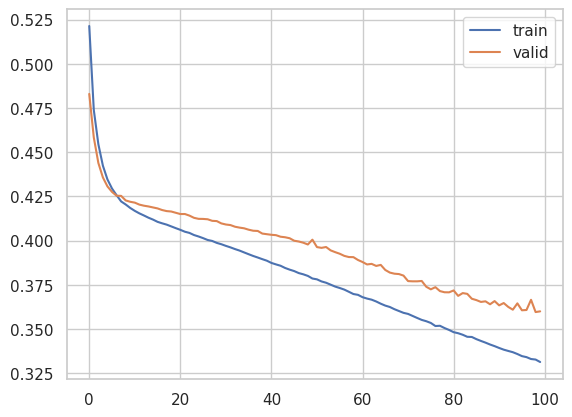

```python
# Capturing learning history per epoch
hist  = pd.DataFrame(history.history)
hist['epoch'] = history.epoch

# Plotting accuracy at different epochs
plt.plot(hist['loss'])
plt.plot(hist['val_loss'])
plt.legend(("train" , "valid") , loc =0)

results = classifier.evaluate(X_test, y_test)
```

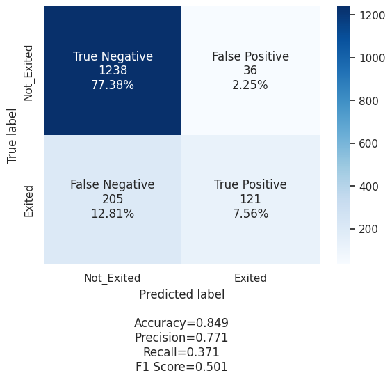

```python
# Obtain predictions on X_val
y_pred1 = classifier.predict(X_val)

# Predict using default threshold (0.5)
y_pred1 = (y_pred1 > 0.5)

# Compute confusion matrix
cm2 = confusion_matrix(y_val, y_pred1)
labels = ['True Negative', 'False Positive', 'False Negative', 'True Positive']
categories = ['Not_Exited', 'Exited']

# Generate confusion matrix plot
make_confusion_matrix(cm2,
                      group_names=labels,
                      categories=categories,
                      cmap='Blues')
```